# XGBoost segmentation

Anais Corral

```r
# Install necessary packages (only once)
#install.packages("dplyr")
#install.packages("readr")

# Load libraries
library(dplyr)
library(readr)
# Load the dataset from the specified path
merged_data_xgb <- readRDS("~/Swire Coca Cola Capstone/merged_data_xgb.rds")

# Check the first few rows to ensure it loaded correctly
head(merged_data_xgb)
```

```
## # A tibble: 6 × 21
##   transaction_date  week  year customer_number order_type    delivered_cases
##   <chr>            <dbl> <dbl>           <dbl> <chr>                   <dbl>
## 1 1/5/2023             1  2023       501202893 MYCOKE LEGACY               1
## 2 1/5/2023             1  2023       501202893 MYCOKE LEGACY               1
## 3 1/5/2023             1  2023       501202893 MYCOKE LEGACY               1
## 4 1/5/2023             1  2023       501202893 MYCOKE LEGACY               1
## 5 1/5/2023             1  2023       501202893 MYCOKE LEGACY               1
## 6 1/5/2023             1  2023       501202893 MYCOKE LEGACY               1
## # ℹ 15 more variables: delivered_gallons <dbl>, primary_group_number <chr>,
## #   frequent_order_type <chr>, first_delivery_date <chr>,
## #   on_boarding_date <chr>, cold_drink_channel <chr>, trade_channel <chr>,
## #   sub_trade_channel <chr>, local_market_partner <lgl>, co2_customer <lgl>,
## #   zip_code <dbl>, median_delivery_cost <dbl>,
## #   predicted_delivered_cases <dbl>, growth_rate_cases <dbl>,
## #   customer_decision <chr>
```

# Threshold-based Segmentation

For example, you could define a growth threshold based on the total number of cases delivered in the most recent time period and then classify customers as follows:

High Growth: Customers who have delivered more than a set threshold of cases.

Medium Growth: Customers who are around the average case deliveries.

```r
# Apply a threshold approach for growth rate categorization
# If growth_rate_cases > 10, classify as "High Growth"
# If growth_rate_cases is between 1 and 10, classify as "Medium Growth"
# If growth_rate_cases is 0 or negative, classify as "Low Growth"
merged_data_xgb$growth_category <- ifelse(merged_data_xgb$growth_rate_cases > 10, "High Growth",
                                           ifelse(merged_data_xgb$growth_rate_cases > 0, "Medium Growth",
                                                  "Low Growth"))

# Check the updated dataset to ensure the growth category has been assigned correctly
head(merged_data_xgb[, c("customer_number", "growth_rate_cases", "growth_category")])
```

```
## # A tibble: 6 × 3
##   customer_number growth_rate_cases growth_category
##             <dbl>             <dbl> <chr>
## 1       501202893              400. High Growth
## 2       501202893              400. High Growth
## 3       501202893              400. High Growth
## 4       501202893              400. High Growth
## 5       501202893              400. High Growth
## 6       501202893              400. High Growth
```

```r
# Optionally, view the counts of each category to ensure the distribution makes sense
table(merged_data_xgb$growth_category)
```

```
##
##   High Growth    Low Growth Medium Growth
##       8484145       4926171        497201
```

**Growth Categories:**

# . Summarize the Segmentation

How many customers belong to each category?

What percentage of total customers fall into each growth category?

This summary will give you insights into how customers are distributed across growth categories. You can do this with a simple count or percentage calculation.

```r
# Count the number of customers in each growth category
growth_summary <- table(merged_data_xgb$growth_category)

# Display the count and percentage of customers in each category
growth_percentage <- prop.table(growth_summary) * 100
growth_summary
```

```
##
##   High Growth    Low Growth Medium Growth
##       8484145       4926171        497201
```

```r
growth_percentage
```

```
##
##   High Growth    Low Growth Medium Growth
##     61.004024     35.420924      3.575052
```

# Visualize the Growth Categories

Create a bar plot to visually represent the distribution of growth categories. This will help stakeholders understand the spread of customers easily.

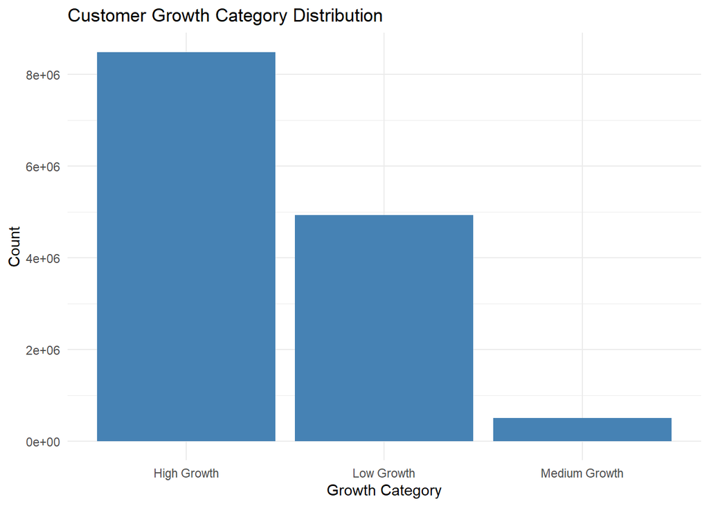

```r
# Load necessary libraries
library(ggplot2)

# Plot the distribution of growth categories
ggplot(data = merged_data_xgb, aes(x = growth_category)) +
  geom_bar(fill = "steelblue") +
  labs(title = "Customer Growth Category Distribution",
       x = "Growth Category", y = "Count") +
  theme_minimal()
```

# High-Growth Customer Analysis:

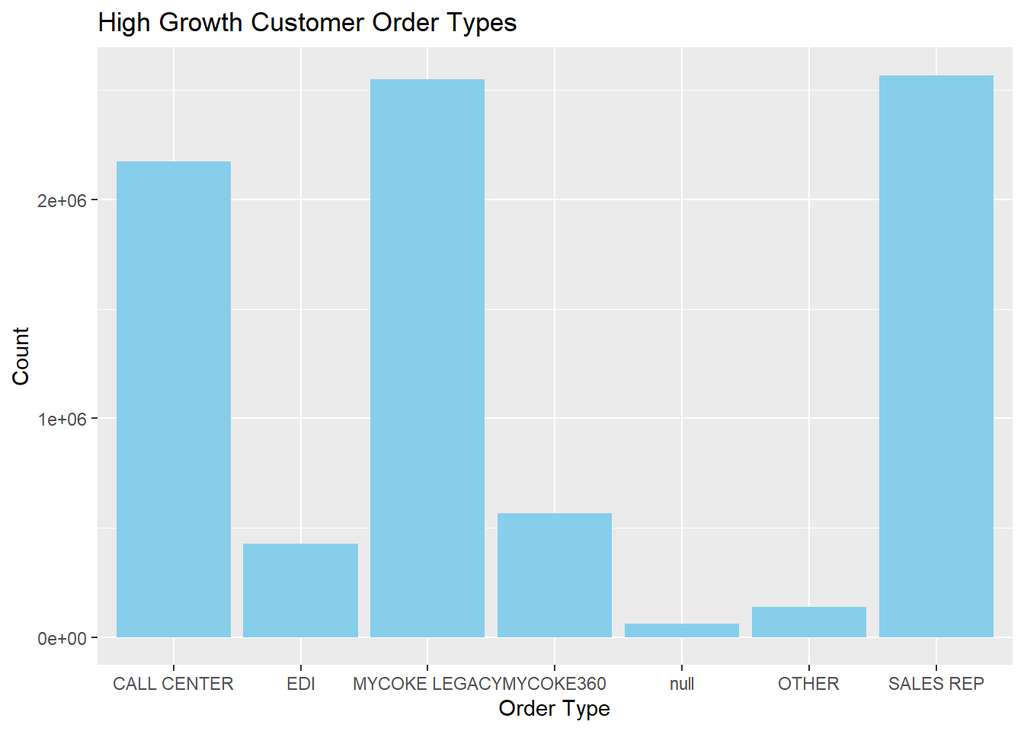

```r
# Load the necessary libraries
library(dplyr)
library(ggplot2)

# Filter the high-growth customers from the dataset
high_growth_customers <- merged_data_xgb %>%
  filter(growth_category == "High Growth")

# Segment by key variables
segmented_high_growth <- high_growth_customers %>%
  select(customer_number, order_type, frequent_order_type, cold_drink_channel,
         trade_channel, zip_code, customer_decision, median_delivery_cost)

# Explore the distribution of these variables for high-growth customers
# Distribution of order types
ggplot(segmented_high_growth, aes(x = order_type)) +
  geom_bar(fill = "skyblue") +
  labs(title = "High Growth Customer Order Types", x = "Order Type", y = "Count")
```

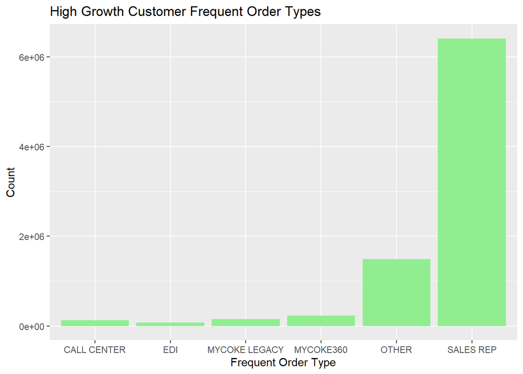

```r
# Distribution of frequent order types
ggplot(segmented_high_growth, aes(x = frequent_order_type)) +
  geom_bar(fill = "lightgreen") +
  labs(title = "High Growth Customer Frequent Order Types", x = "Frequent Order Type", y = "Count")
```

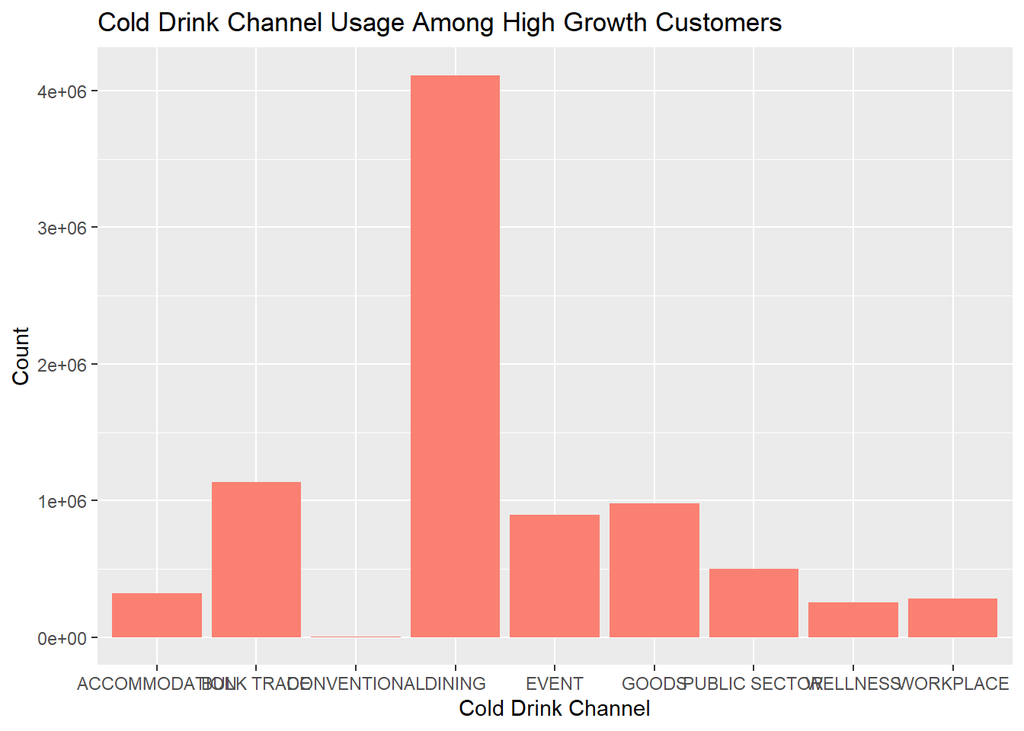

```r
# Distribution of cold drink channel usage
ggplot(segmented_high_growth, aes(x = cold_drink_channel)) +
  geom_bar(fill = "salmon") +
  labs(title = "Cold Drink Channel Usage Among High Growth Customers", x = "Cold Drink Channel", y = "Count")
```

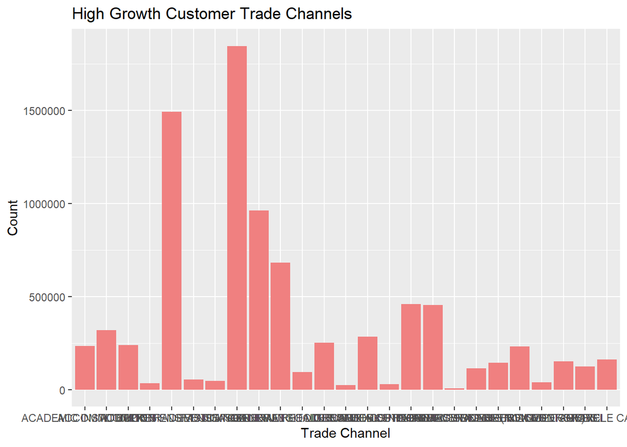

```r
# Distribution of trade channels
ggplot(segmented_high_growth, aes(x = trade_channel)) +
  geom_bar(fill = "lightcoral") +
  labs(title = "High Growth Customer Trade Channels", x = "Trade Channel", y = "Count")
```

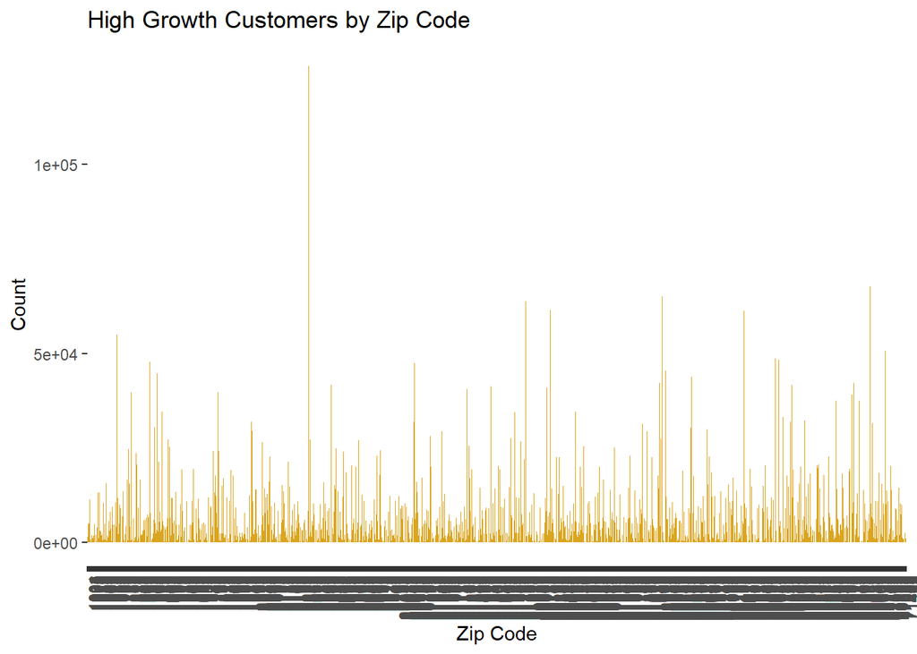

```r
# Distribution of high growth customers by zip code (to identify regional trends)
ggplot(segmented_high_growth, aes(x = factor(zip_code))) +
  geom_bar(fill = "goldenrod") +
  labs(title = "High Growth Customers by Zip Code", x = "Zip Code", y = "Count") +
  theme(axis.text.x = element_text(angle = 90, hjust = 1))
```

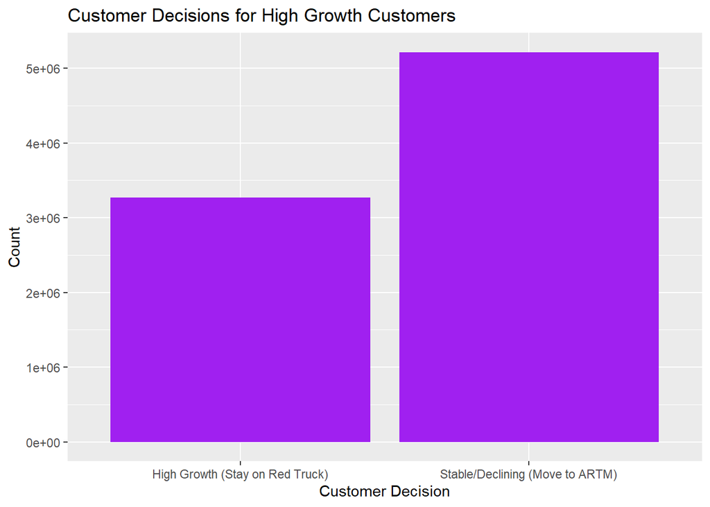

```r
# Customer decision (whether they stay or switch)
ggplot(segmented_high_growth, aes(x = customer_decision)) +
  geom_bar(fill = "purple") +
  labs(title = "Customer Decisions for High Growth Customers", x = "Customer Decision", y = "Count")
```

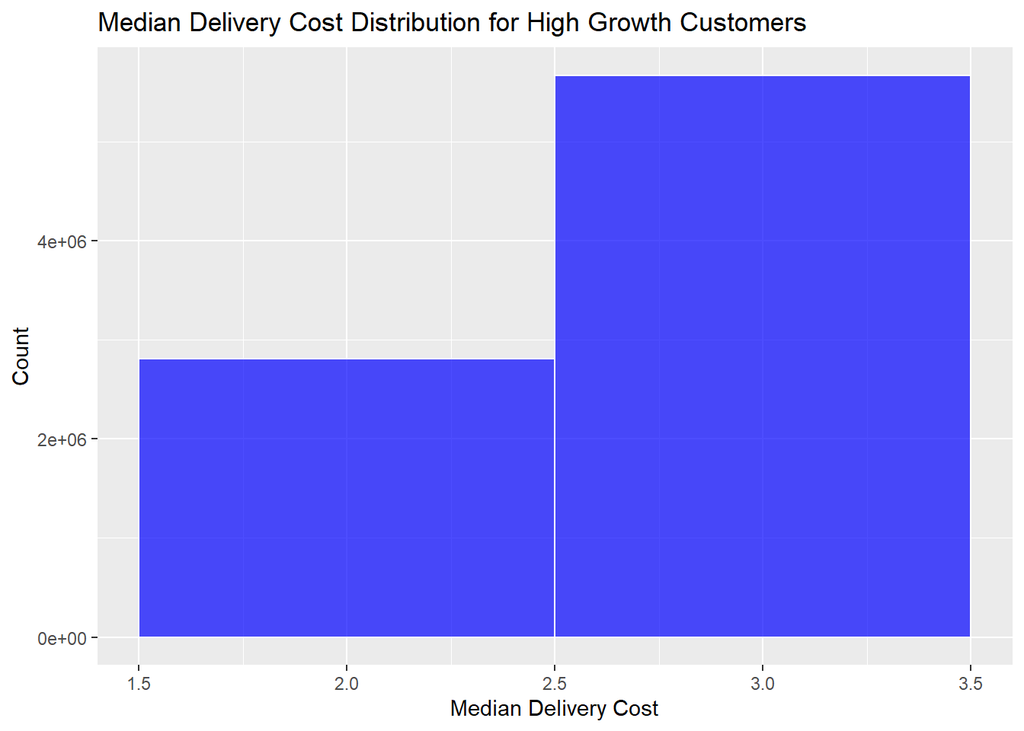

```r
# Analyze median delivery cost for high-growth customers
ggplot(segmented_high_growth, aes(x = median_delivery_cost)) +
  geom_histogram(binwidth = 1, fill = "blue", color = "white", alpha = 0.7) +
  labs(title = "Median Delivery Cost Distribution for High Growth Customers", x = "Median Delivery Cost", y = "Count")
```

```r
# View the segmented high-growth customer data
head(segmented_high_growth)
```

```
## # A tibble: 6 × 8
##   customer_number order_type    frequent_order_type cold_drink_channel
##             <dbl> <chr>         <chr>               <chr>
## 1       501202893 MYCOKE LEGACY SALES REP           DINING
## 2       501202893 MYCOKE LEGACY SALES REP           DINING
## 3       501202893 MYCOKE LEGACY SALES REP           DINING
## 4       501202893 MYCOKE LEGACY SALES REP           DINING
## 5       501202893 MYCOKE LEGACY SALES REP           DINING
## 6       501202893 MYCOKE LEGACY SALES REP           DINING
## # ℹ 4 more variables: trade_channel <chr>, zip_code <dbl>,
## #   customer_decision <chr>, median_delivery_cost <dbl>
```

# Top 5 Order Types for High Growth Customers

top 5 values for each of the most important variables in your dataset: Order Type, Frequent Order Type, Cold Drink Channel, Trade Channel, Zip Code, Median Delivery Cost, and Customer Decision.

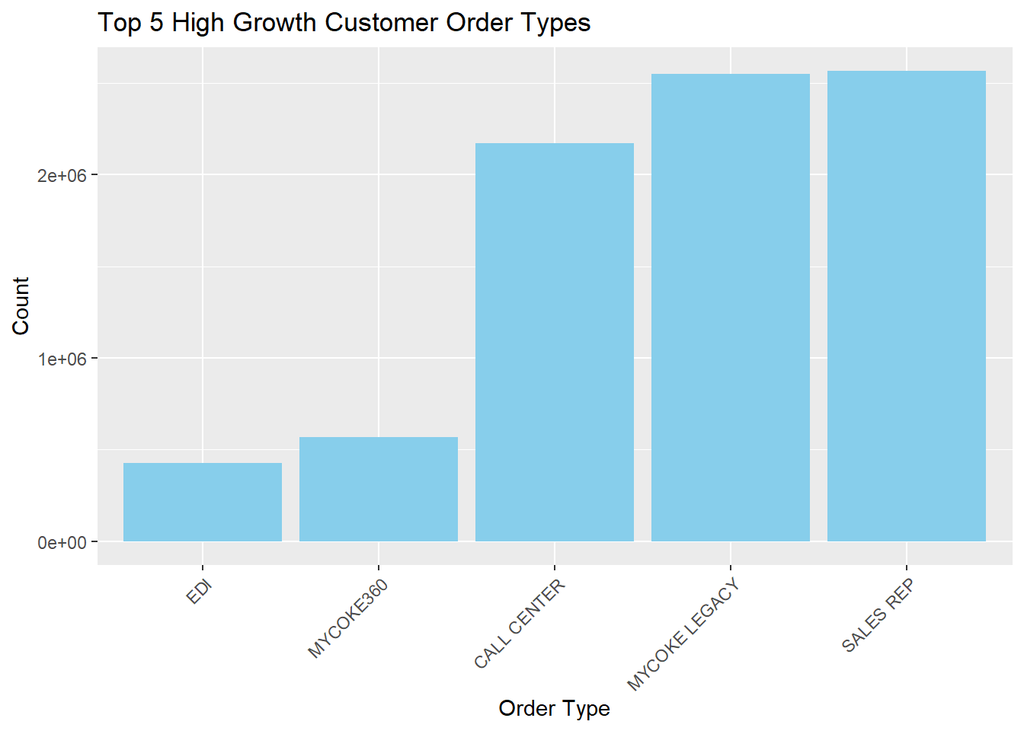

```r
# Top 5 order types for high growth customers
high_growth_customers %>%
  filter(growth_category == "High Growth") %>%
  group_by(order_type) %>%
  summarise(count = n()) %>%
  arrange(desc(count)) %>%
  top_n(5) %>%
  ggplot(aes(x = reorder(order_type, count), y = count)) +
  geom_bar(stat = "identity", fill = "skyblue") +
  theme(axis.text.x = element_text(angle = 45, hjust = 1)) +
  labs(title = "Top 5 High Growth Customer Order Types", x = "Order Type", y = "Count")
```

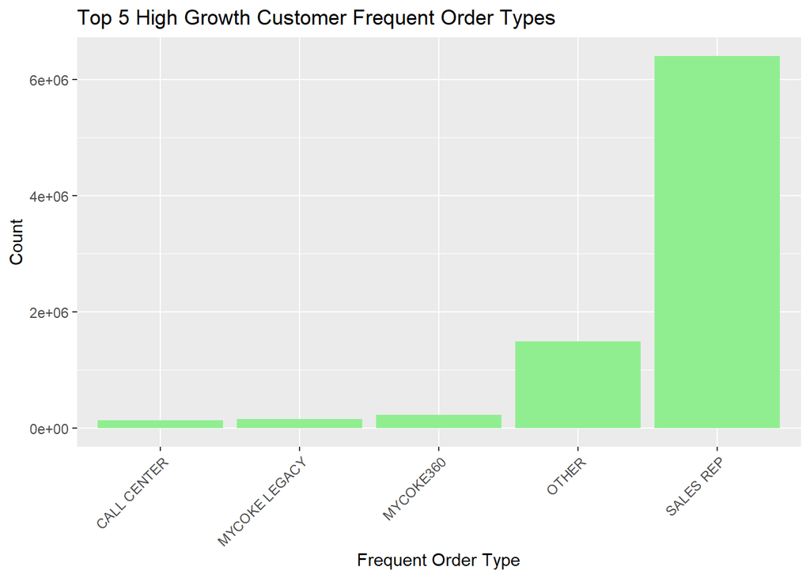

```r
# Top 5 frequent order types for high growth customers
high_growth_customers %>%
  filter(growth_category == "High Growth") %>%
  group_by(frequent_order_type) %>%
  summarise(count = n()) %>%
  arrange(desc(count)) %>%
  top_n(5) %>%
  ggplot(aes(x = reorder(frequent_order_type, count), y = count)) +
  geom_bar(stat = "identity", fill = "lightgreen") +
  theme(axis.text.x = element_text(angle = 45, hjust = 1)) +
  labs(title = "Top 5 High Growth Customer Frequent Order Types", x = "Frequent Order Type", y = "Count")
```

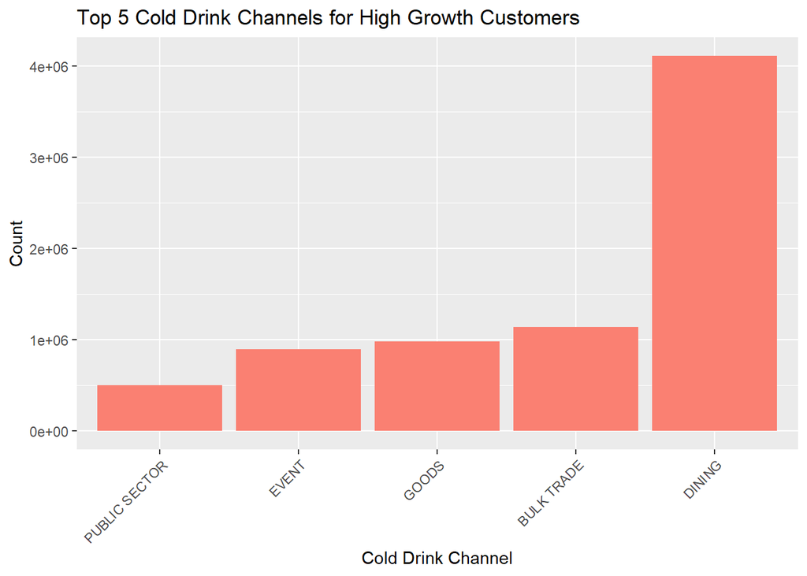

```r
# Top 5 cold drink channels for high growth customers
high_growth_customers %>%
  filter(growth_category == "High Growth") %>%
  group_by(cold_drink_channel) %>%
  summarise(count = n()) %>%
  arrange(desc(count)) %>%
  top_n(5) %>%
  ggplot(aes(x = reorder(cold_drink_channel, count), y = count)) +
  geom_bar(stat = "identity", fill = "salmon") +
  theme(axis.text.x = element_text(angle = 45, hjust = 1)) +
  labs(title = "Top 5 Cold Drink Channels for High Growth Customers", x = "Cold Drink Channel", y = "Count")
```

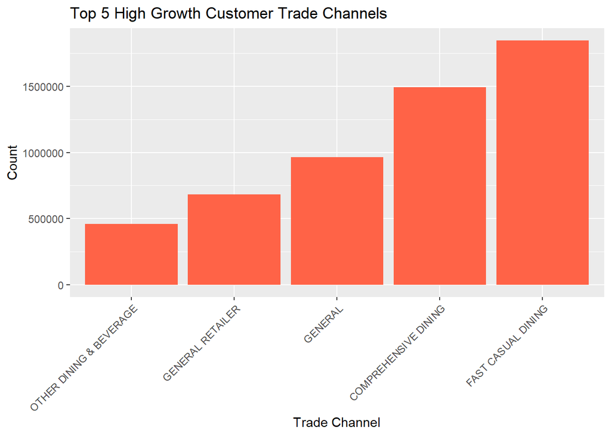

```r
# Top 5 trade channels for high growth customers
high_growth_customers %>%
  filter(growth_category == "High Growth") %>%
  group_by(trade_channel) %>%
  summarise(count = n()) %>%
  arrange(desc(count)) %>%
  top_n(5) %>%
  ggplot(aes(x = reorder(trade_channel, count), y = count)) +
  geom_bar(stat = "identity", fill = "tomato") +
  theme(axis.text.x = element_text(angle = 45, hjust = 1)) +
  labs(title = "Top 5 High Growth Customer Trade Channels", x = "Trade Channel", y = "Count")
```

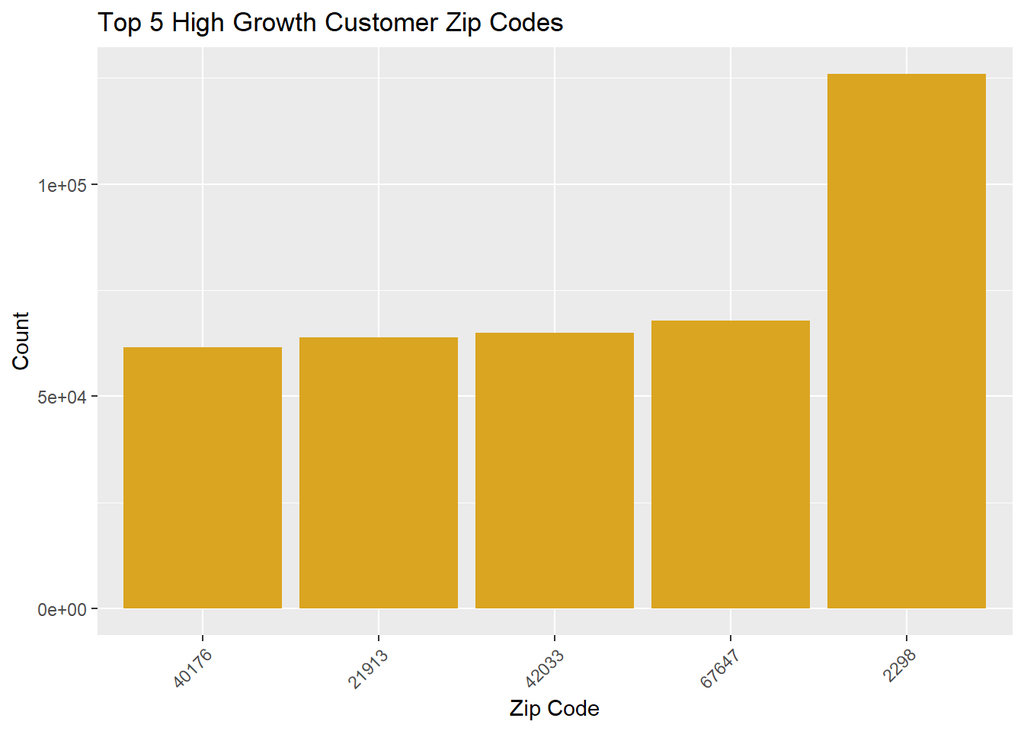

```r
# Top 5 zip codes for high growth customers
high_growth_customers %>%
  filter(growth_category == "High Growth") %>%
  group_by(zip_code) %>%
  summarise(count = n()) %>%
  arrange(desc(count)) %>%
  top_n(5) %>%
  ggplot(aes(x = reorder(as.factor(zip_code), count), y = count)) +
  geom_bar(stat = "identity", fill = "goldenrod") +
  theme(axis.text.x = element_text(angle = 45, hjust = 1)) +
  labs(title = "Top 5 High Growth Customer Zip Codes", x = "Zip Code", y = "Count")
```

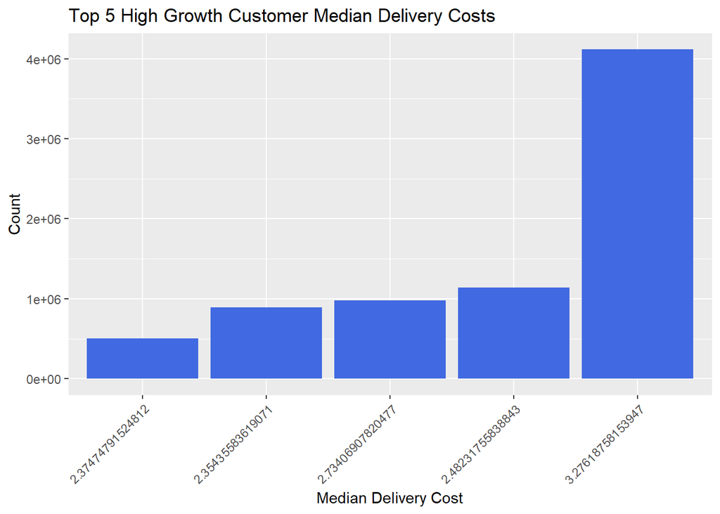

```r
# Top 5 median delivery costs for high growth customers
high_growth_customers %>%
  filter(growth_category == "High Growth") %>%
  group_by(median_delivery_cost) %>%
  summarise(count = n()) %>%
  arrange(desc(count)) %>%
  top_n(5) %>%
  ggplot(aes(x = reorder(as.factor(median_delivery_cost), count), y = count)) +
  geom_bar(stat = "identity", fill = "royalblue") +
  theme(axis.text.x = element_text(angle = 45, hjust = 1)) +
  labs(title = "Top 5 High Growth Customer Median Delivery Costs", x = "Median Delivery Cost", y = "Count")
```

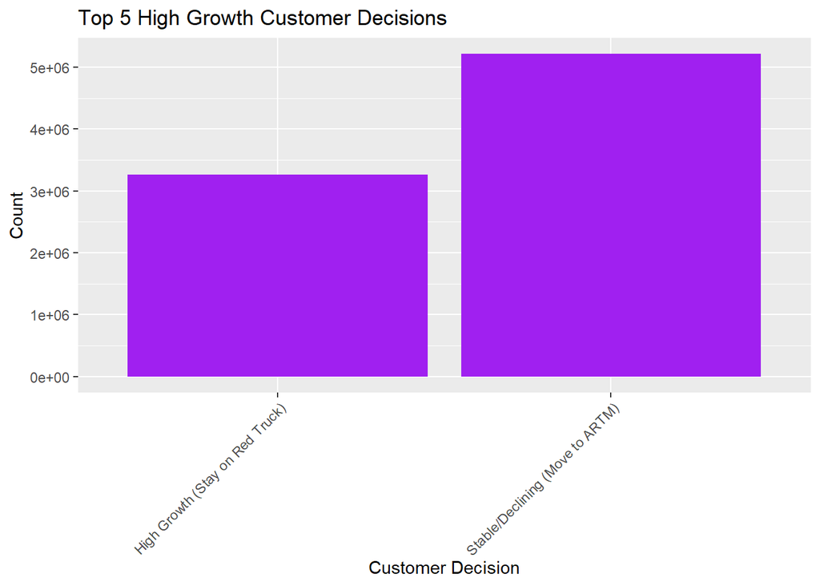

```r
# Top 5 customer decisions for high growth customers
high_growth_customers %>%
  filter(growth_category == "High Growth") %>%
  group_by(customer_decision) %>%
  summarise(count = n()) %>%
  arrange(desc(count)) %>%
  top_n(5) %>%
  ggplot(aes(x = reorder(customer_decision, count), y = count)) +
  geom_bar(stat = "identity", fill = "purple") +
  theme(axis.text.x = element_text(angle = 45, hjust = 1)) +
  labs(title = "Top 5 High Growth Customer Decisions", x = "Customer Decision", y = "Count")
```

**Summary of Findings**

This metric tells us about the “typical” or “central” cost of delivering goods to customers within each segment.

In simple terms: lower delivery costs mean higher profit margins for Swire Coca-Cola, and focusing on reducing these costs for high-growth customers can improve their profitability.

- **Customer Decision:** Most high-growth customers are in the “Stable/Declining” category. Swire Coca-Cola should work on converting these customers to higher-growth segments.

“Stable/Declining” refers to customers whose demand or volume is not growing. These customers might have seen a slowdown in their orders, or their orders are consistent but not increasing. This group is in contrast to “High Growth” customers, whose order volume is increasing.

We categorized customers as “Stable/Declining” based on either historical order trends or growth rate. If a customer’s order volume showed little or no increase over time, they were considered “Stable/Declining.”

## How we categorize “High Growth” customers:

In simpler terms: customers who had significant historical increases in their delivered cases were classified as high-growth, and we categorized those customers based on actual growth trends.

- If asked during the presentation, you can confidently say that “High Growth” customers were identified based on their historical increases in delivered cases, which helps predict their future behavior and optimize logistics accordingly.

# Find High-Cost, High-Growth Customers:

```r
# Subset the data to include only relevant columns for analysis
subset_data <- merged_data_xgb %>%
  select(customer_number, order_type, cold_drink_channel, trade_channel, zip_code, median_delivery_cost, growth_category)

# Group by growth category and calculate summary statistics
summary_data <- subset_data %>%
  group_by(growth_category) %>%
  summarise(
    avg_delivery_cost = mean(median_delivery_cost, na.rm = TRUE),
    min_delivery_cost = min(median_delivery_cost, na.rm = TRUE),
    max_delivery_cost = max(median_delivery_cost, na.rm = TRUE),
    count = n()
  )

# Show the summary data
print(summary_data)
```

```
## # A tibble: 3 × 5
##   growth_category avg_delivery_cost min_delivery_cost max_delivery_cost   count
##   <chr>                       <dbl>             <dbl>             <dbl>   <int>
## 1 High Growth                  2.88              2.02              3.28 8484145
## 2 Low Growth                   2.88              2.02              3.28 4926171
## 3 Medium Growth                2.84              2.02              3.28  497201
```

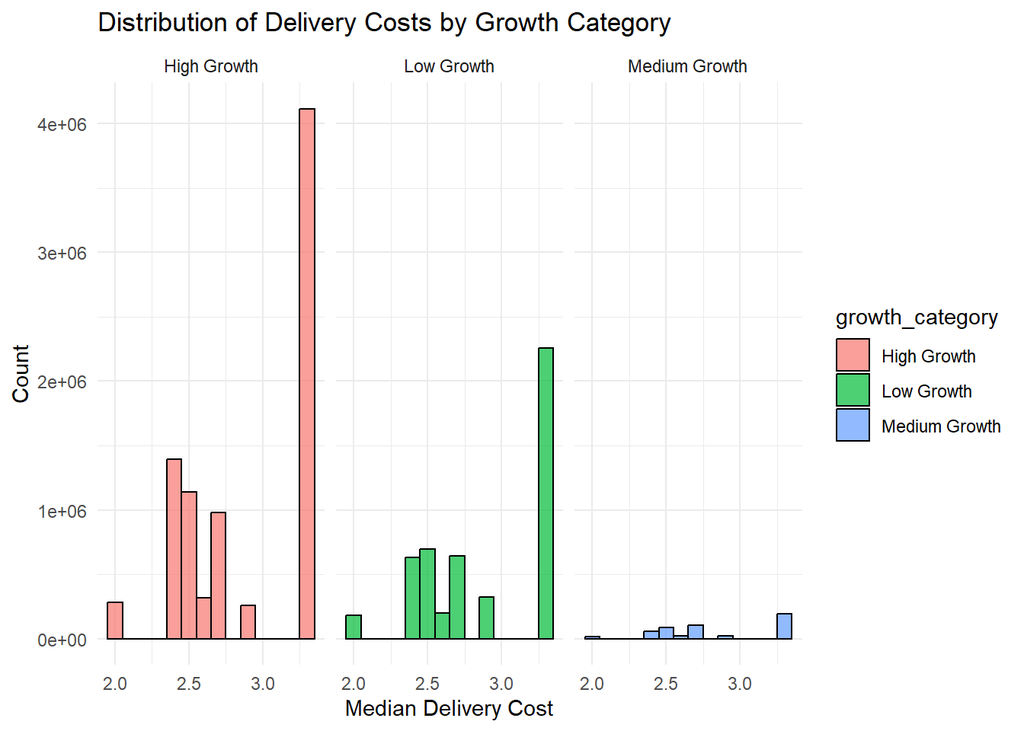

```r
# Create visualization to analyze the most expensive delivery costs within growth categories
ggplot(subset_data, aes(x = median_delivery_cost, fill = growth_category)) +
  geom_histogram(binwidth = 0.1, color = "black", alpha = 0.7) +
  facet_wrap(~ growth_category) +
  labs(title = "Distribution of Delivery Costs by Growth Category",
       x = "Median Delivery Cost",
       y = "Count") +
  theme_minimal()
```

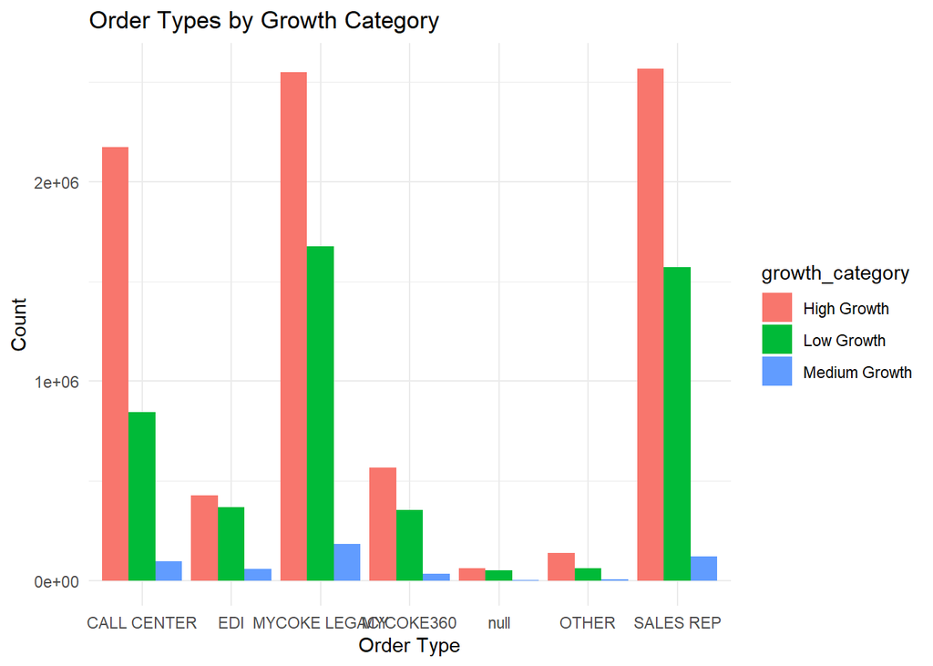

```r
# Visualize the order types by growth category
ggplot(subset_data, aes(x = order_type, fill = growth_category)) +
  geom_bar(position = "dodge") +
  labs(title = "Order Types by Growth Category",
       x = "Order Type",
       y = "Count") +
  theme(axis.text.x = element_text(angle = 45, hjust = 1)) +
  theme_minimal()
```

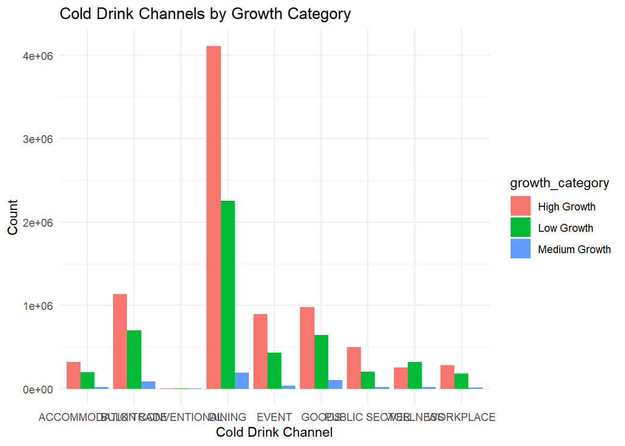

```r
# Visualize cold drink channels by growth category
ggplot(subset_data, aes(x = cold_drink_channel, fill = growth_category)) +
  geom_bar(position = "dodge") +
  labs(title = "Cold Drink Channels by Growth Category",
       x = "Cold Drink Channel",
       y = "Count") +
  theme(axis.text.x = element_text(angle = 45, hjust = 1)) +
  theme_minimal()
```